# R Notebook

# 25 February 2020

## Loading in SD Data

```r
Kobe.Ian = read_excel('Play Exp 1 (SD) Data (1).xlsx', sheet = 'P1_Kobe&Ian')
Sally.Vanya = read_excel('Play Exp 1 (SD) Data (1).xlsx', sheet = 'P2_Sally&Vanya')
Rocky.Oaky = read_excel('Play Exp 1 (SD) Data (1).xlsx', sheet = 'P3_Rocky&Oaky')
Rosie.Carlie = read_excel('Play Exp 1 (SD) Data (1).xlsx', sheet = 'P4_Rosie&Carlie')
Koda.Ava = read_excel('Play Exp 1 (SD) Data (1).xlsx', sheet = 'P5_Koda&Ava')
Kodi.Kaia = read_excel('Play Exp 1 (SD) Data (1).xlsx', sheet = 'P6_Kodi & Kaia')
Dax.Fiona = read_excel('Play Exp 1 (SD) Data (1).xlsx', sheet = 'P7_Dax & Fiona')
Mason.Coffee = read_excel('Play Exp 1 (SD) Data (1).xlsx', sheet = 'P8_Mason&Coffee')
Gunner.Cato = read_excel('Play Exp 1 (SD) Data (1).xlsx', sheet = 'P9_Gunner&Cato')
Misha.Houston = read_excel('Play Exp 1 (SD) Data (1).xlsx', sheet = 'P10_Misha&Houston')
Rev.Blitz = read_excel('Play Exp 1 (SD) Data (1).xlsx', sheet = 'P11_Rev&Blitz')
Jude.Luna = read_excel('Play Exp 1 (SD) Data (1).xlsx', sheet = 'P12_Jude&Luna')
```

## Descriptives for the SD Data

### Kobe & Ian

```r
library(mosaic)
favstats(~Kobe.Ian$SD)
```

|  | min | Q1 | median | Q3 | max | mean | sd | n | missing |
| --- | --- | --- | --- | --- | --- | --- | --- | --- | --- |
|  | 3 | 24.25 | 120.5 | 219.25 | 234 | 120.5 | 98.01049 | 10 | 0 |

```r
favstats(~Kobe.Ian$`S-Delta`)
```

|  | min | Q1 | median | Q3 | max | mean | sd | n | missing |
| --- | --- | --- | --- | --- | --- | --- | --- | --- | --- |
|  | 0 | 0 | 0 | 0 | 0 | 0 | 0 | 10 | 0 |

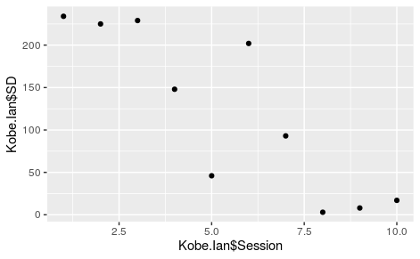

```r
gf_point(Kobe.Ian$SD~Kobe.Ian$Session)
```

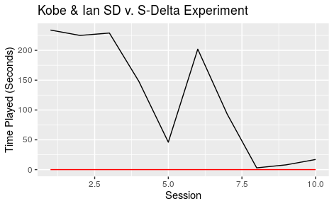

```r
gf_line(Kobe.Ian$SD~Kobe.Ian$Session) %>% gf_line(Kobe.Ian$`S-Delta`~Kobe.Ian$Session, color = 'red') %>% gf_labs(title = 'Kobe & Ian SD v. S-Delta Experiment', x = 'Session' , y = 'Time Played (Seconds)')
```

### Sally & Vanya

```r
library(mosaic)
favstats(~Sally.Vanya$`Percent of Scored Intervals in SD...10`)
```

|  | min | Q1 | median | Q3 | max | mean | sd | n | missing |
| --- | --- | --- | --- | --- | --- | --- | --- | --- | --- |
|  | 0 | 86 | 135 | 148.75 | 200 | 120.9 | 59.17291 | 10 | 0 |

```r
favstats(~Sally.Vanya$`Percent of Scored Intervals in S-delta...11`)
```

|  | min | Q1 | median | Q3 | max | mean | sd | n | missing |
| --- | --- | --- | --- | --- | --- | --- | --- | --- | --- |
|  | 0 | 0 | 65 | 200 | 270 | 100 | 113.2353 | 10 | 0 |

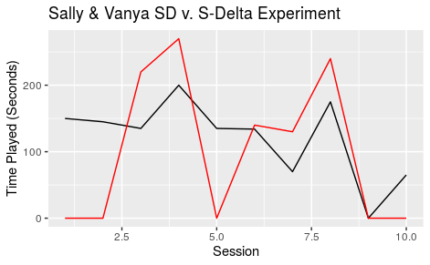

```r
gf_line(Sally.Vanya$`Percent of Scored Intervals in SD...10`~Sally.Vanya$Session...1) %>% gf_line(Sally.Vanya$`Percent of Scored Intervals in S-delta...11`~Sally.Vanya$Session...1, color = 'red') %>% gf_labs(title = 'Sally & Vanya SD v. S-Delta Experiment', x = 'Session', y = 'Time Played (Seconds)')
```

### Rocky & Oaky

```r
library(mosaic)
favstats(~Rocky.Oaky$`SD (s)`)
```

|  | min | Q1 | median | Q3 | max | mean | sd | n | missing |
| --- | --- | --- | --- | --- | --- | --- | --- | --- | --- |
|  | 15 | 53.75 | 115 | 178.75 | 260 | 122 | 80.11103 | 10 | 0 |

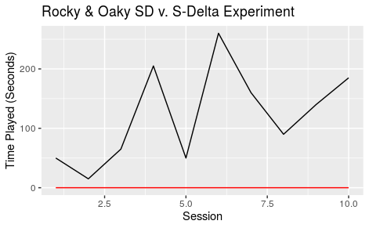

```r
gf_line(Rocky.Oaky$`SD (s)`~Rocky.Oaky$Session...2) %>% gf_line(Rocky.Oaky$`S-Delta (s)`~Rocky.Oaky$Session...2, color = 'red') %>% gf_labs(title =  'Rocky & Oaky SD v. S-Delta Experiment', x = 'Session', y = 'Time Played (Seconds)')
```

### Rosie & Carlie

```r
library(mosaic)
favstats(~Rosie.Carlie$`SD (s)`)
```

|  | min | Q1 | median | Q3 | max | mean | sd | n | missing |
| --- | --- | --- | --- | --- | --- | --- | --- | --- | --- |
|  | 0 | 1.25 | 12.5 | 27.5 | 35 | 15 | 14.7196 | 10 | 0 |

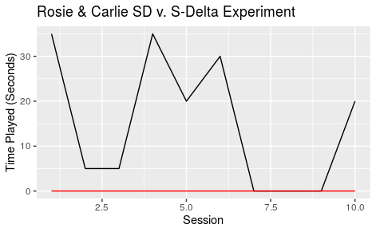

```r
gf_line(Rosie.Carlie$`SD (s)`~Rosie.Carlie$Session...2) %>% gf_line(Rosie.Carlie$`S-Delta (s)`~Rosie.Carlie$Session...2, color = 'red') %>% gf_labs(title = 'Rosie & Carlie SD v. S-Delta Experiment', x = 'Session', y = 'Time Played (Seconds)')
```

### Koda & Ava

```r
library(mosaic)
favstats(~Koda.Ava$`SD (Attention)`)
```

|  | min | Q1 | median | Q3 | max | mean | sd | n | missing |
| --- | --- | --- | --- | --- | --- | --- | --- | --- | --- |
|  | 0 | 0 | 0 | 0 | 18 | 1.8 | 5.6921 | 10 | 0 |

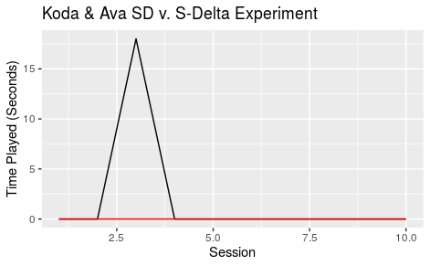

```r
gf_line(Koda.Ava$`SD (Attention)`~Koda.Ava$Session) %>% gf_line(Koda.Ava$`S-Delta (No Attention)`~Koda.Ava$Session, color = 'red') %>% gf_labs(title = 'Koda & Ava SD v. S-Delta Experiment', x = 'Session', y = 'Time Played (Seconds)')
```

### Kodi & Kaia

```r
library(mosaic)
favstats(~Kodi.Kaia$`SD (s)`)
```

|  | min | Q1 | median | Q3 | max | mean | sd | n | missing |
| --- | --- | --- | --- | --- | --- | --- | --- | --- | --- |
|  | 0 | 67.5 | 95 | 155 | 200 | 99.5 | 68.65574 | 10 | 0 |

```r
favstats(~Kodi.Kaia$`S-Delta (s)`)
```

|  | min | Q1 | median | Q3 | max | mean | sd | n | missing |
| --- | --- | --- | --- | --- | --- | --- | --- | --- | --- |
|  | 0 | 0 | 0 | 0 | 110 | 19.5 | 41.52978 | 10 | 0 |

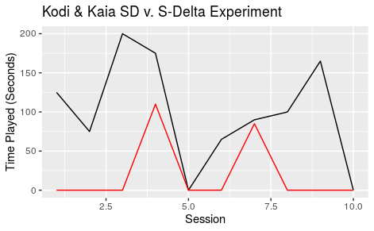

```r
gf_line(Kodi.Kaia$`SD (s)`~Kodi.Kaia$Session...2) %>% gf_line(Kodi.Kaia$`S-Delta (s)`~Kodi.Kaia$Session...2, color = 'red') %>% gf_labs(title = 'Kodi & Kaia SD v. S-Delta Experiment', x = 'Session', y = 'Time Played (Seconds)')
```

The above shows descriptive statistics ran for my assigned dog pairs. Each bit of information contains code used to run the descriptives as well as line plots resembling those of which are found on the excel spreadsheets given by the client.

## Loading in EO Data

```r
Kobe.Ian.EO = read_excel('Play Exp 2 (EO) Data (1).xlsx', sheet = 'P1_Kobe&Ian')
Sally.Vanya.EO = read_excel('Play Exp 2 (EO) Data (1).xlsx', sheet = 'P2_Sally&Vanya')
```

```
* `` -> ...5
```

```r
Rocky.Oaky.EO = read_excel('Play Exp 2 (EO) Data (1).xlsx', sheet = 'P3_Rocky&Oaky')
```

```
* `` -> ...6
* `` -> ...7
* `` -> ...8
* `` -> ...9
* `` -> ...10
```

```r
Rosie.Carlie.EO = read_excel('Play Exp 2 (EO) Data (1).xlsx', sheet = 'P4_Rosie&Carlie')
```

```
* `` -> ...6
* `` -> ...7
* `` -> ...8
* `` -> ...9
* `` -> ...10
* … and 1 more problem
```

```r
Koda.Ava.EO = read_excel('Play Exp 2 (EO) Data (1).xlsx', sheet = 'P5_Koda&Ava')
Kodi.Kaia.EO = read_excel('Play Exp 2 (EO) Data (1).xlsx', sheet = 'P6_Kodi & Kaia')
```

```
* `` -> ...6
* `` -> ...7
* `` -> ...8
* `` -> ...9
* `` -> ...10
```

## Descriptives for EO Data

### Kobe & Ian

### Sally & Vanya

### Rocky & Oaky

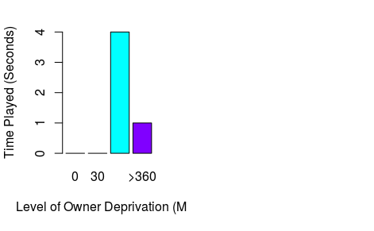

```r
par(mfrow = c(1,2))
barplot(c(0, 0, 4, 1), names.arg = c('0', '30', '120', '>360'), ylim = c(0, 4), xlab = 'Level of Owner Deprivation (Min)', ylab = 'Time Played (Seconds)', col = rainbow(4))
barplot(c(164, 0, 28, 99), names.arg = c('0', '30', '120', '>360'), ylim = c(0, 164), xlab = 'Level of Owner Deprivation (Min)', ylab = 'Time Played (Seconds)', col = rainbow(4))
```

### Rosie & Carlie

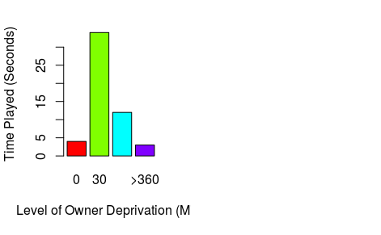

```r
par(mfrow = c(1,2))
barplot(c(4, 34, 12, 3), names.arg = c('0', '30', '120', '>360'), ylim = c(0, 34), xlab = 'Level of Owner Deprivation (Min)', ylab = 'Time Played (Seconds)', col = rainbow(4))
barplot(c(9, 19, 21, 6), names.arg = c('0', '30', '120', '>360'), ylim = c(0, 21), xlab = 'Level of Owner Deprivation (Min)', ylab = 'Time Played (Seconds)', col = rainbow(4))
```

### Kodi & Kaia

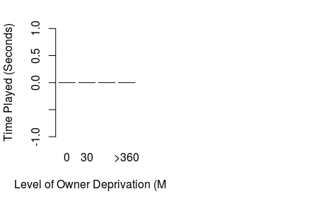

```r
par(mfrow = c(1,2))
barplot(c(0, 0, 0, 0), names.arg = c('0', '30', '120', '>360'), ylim = c(0, 0), xlab = 'Level of Owner Deprivation (Min)', ylab = 'Time Played (Seconds)', col = rainbow(4))
barplot(c(0, 0, 0, 0), names.arg = c('0', '30', '120', '>360'), ylim = c(0, 0), xlab = 'Level of Owner Deprivation (Min)', ylab = 'Time Played (Seconds)', col = rainbow(4))
```

The above illustrates descriptive statistics of the EO datset ran for my assigned pairs of dogs. Plots illustrate an overlay chart of the time played in seconds (y-axis) and level of owner deprivation in minutes (x-axis).

## Loading in Reinforced Data

```r
Kobe.Ian.Rein = read_excel('Play Exp 3 (Reinforcer) Data (1).xlsx', sheet = 'P1_Kobe&Ian')
Sally.Vanya.Rein = read_excel('Play Exp 3 (Reinforcer) Data (1).xlsx', sheet = 'P2_Sally&Vanya')
```

```
* `` -> ...6
* `` -> ...7
* `` -> ...8
* `` -> ...9
* `` -> ...10
```

```r
Rocky.Oaky.Rein = read_excel('Play Exp 3 (Reinforcer) Data (1).xlsx', sheet = 'P3_Rocky&Oaky')
```

```
* `` -> ...6
* `` -> ...7
* `` -> ...8
* `` -> ...9
* `` -> ...10
* … and 1 more problem
```

```r
Rosie.Carlie.Rein = read_excel('Play Exp 3 (Reinforcer) Data (1).xlsx', sheet = 'P4_Rosie&Carlie')
```

```
* `` -> ...6
* `` -> ...7
* `` -> ...8
* `` -> ...9
* `` -> ...10
```

```r
Jude.Luna.Rein = read_excel('Play Exp 3 (Reinforcer) Data (1).xlsx', sheet = 'P5_Jude&Luna')
Kodi.Kaia.Rein = read_excel('Play Exp 3 (Reinforcer) Data (1).xlsx', sheet = 'P6_Kodi & Kaia')
```

```
* `` -> ...6
* `` -> ...7
* `` -> ...8
* `` -> ...9
* `` -> ...10
```

## Descriptives for Reinforced Data

### Kobe & Ian

### Sally & Vanya

```r
favstats(Sally.Vanya.Rein$`Attention Control`)
```

|  | min | Q1 | median | Q3 | max | mean | sd | n | missing |
| --- | --- | --- | --- | --- | --- | --- | --- | --- | --- |
|  | 0 | 0 | 0 | 0 | 0 | 0 | 0 | 6 | 9 |

```r
favstats(Sally.Vanya.Rein$`Attention Test`)
```

|  | min | Q1 | median | Q3 | max | mean | sd | n | missing |
| --- | --- | --- | --- | --- | --- | --- | --- | --- | --- |
|  | 0 | 0 | 0 | 0 | 0 | 0 | 0 | 6 | 9 |

```r
favstats(Sally.Vanya.Rein$Alone)
```

|  | min | Q1 | median | Q3 | max | mean | sd | n | missing |
| --- | --- | --- | --- | --- | --- | --- | --- | --- | --- |
|  | 0 | 0 | 0 | 0 | 0 | 0 | 0 | 6 | 9 |

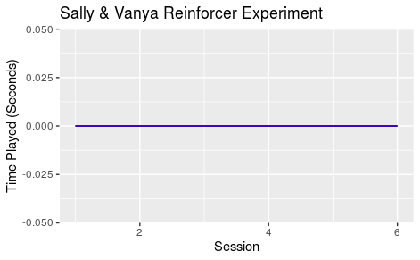

```r
gf_line(Sally.Vanya.Rein$`Attention Control`~Sally.Vanya.Rein$Session) %>% gf_line(Sally.Vanya.Rein$`Attention Test`~Sally.Vanya.Rein$Session, color = 'red') %>% gf_line(Sally.Vanya.Rein$Alone~Sally.Vanya.Rein$Session, color = 'blue') %>% gf_labs(title = 'Sally & Vanya Reinforcer Experiment', x = 'Session', y = 'Time Played (Seconds)')
```

### Rocky & Oaky

```r
favstats(Rocky.Oaky.Rein$`Attention Control`)
```

|  | min | Q1 | median | Q3 | max | mean | sd | n | missing |
| --- | --- | --- | --- | --- | --- | --- | --- | --- | --- |
|  | 137 | 157.5 | 175.5 | 192.75 | 210 | 174.6667 | 27.78969 | 6 | 16 |

```r
favstats(Rocky.Oaky.Rein$`Attention Test`)
```

|  | min | Q1 | median | Q3 | max | mean | sd | n | missing |
| --- | --- | --- | --- | --- | --- | --- | --- | --- | --- |
|  | 0 | 0 | 0 | 0 | 20 | 3.333333 | 8.164966 | 6 | 16 |

```r
favstats(Rocky.Oaky.Rein$Alone)
```

|  | min | Q1 | median | Q3 | max | mean | sd | n | missing |
| --- | --- | --- | --- | --- | --- | --- | --- | --- | --- |
|  | 0 | 0 | 0 | 0 | 0 | 0 | 0 | 6 | 16 |

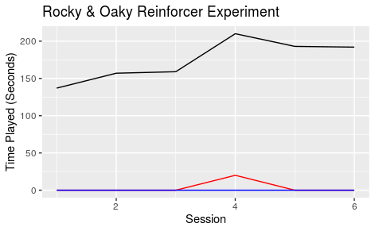

```r
gf_line(Rocky.Oaky.Rein$`Attention Control`~Rocky.Oaky.Rein$Session) %>% gf_line(Rocky.Oaky.Rein$`Attention Test`~Rocky.Oaky.Rein$Session, color = 'red') %>% gf_line(Rocky.Oaky.Rein$Alone~Rocky.Oaky.Rein$Session, color = 'blue') %>% gf_labs(title = 'Rocky & Oaky Reinforcer Experiment', x = 'Session', y = 'Time Played (Seconds)')
```

# 3 March 2020

### Rosie & Carlie

```r
favstats(Rosie.Carlie.Rein$`Attention Control`)
```

|  | min | Q1 | median | Q3 | max | mean | sd | n | missing |
| --- | --- | --- | --- | --- | --- | --- | --- | --- | --- |
|  | 0 | 0 | 0 | 0 | 7 | 1.166667 | 2.857738 | 6 | 4 |

```r
favstats(Rosie.Carlie.Rein$`Attention Test`)
```

|  | min | Q1 | median | Q3 | max | mean | sd | n | missing |
| --- | --- | --- | --- | --- | --- | --- | --- | --- | --- |
|  | 0 | 0 | 0 | 0 | 0 | 0 | 0 | 6 | 4 |

```r
favstats(Rosie.Carlie.Rein$Alone)
```

|  | min | Q1 | median | Q3 | max | mean | sd | n | missing |
| --- | --- | --- | --- | --- | --- | --- | --- | --- | --- |
|  | 0 | 0 | 0 | 0 | 0 | 0 | 0 | 6 | 4 |

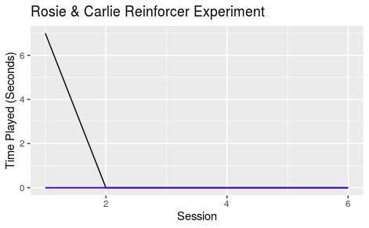

```r
gf_line(Rosie.Carlie.Rein$`Attention Control`~Rosie.Carlie.Rein$Session) %>% gf_line(Rosie.Carlie.Rein$`Attention Test`~Rosie.Carlie.Rein$Session, color = 'red') %>% gf_line(Rosie.Carlie.Rein$Alone~Rosie.Carlie.Rein$Session, color = 'blue') %>% gf_labs(title = 'Rosie & Carlie Reinforcer Experiment', x = 'Session', y = 'Time Played (Seconds)')
```

### Jude & Luna

### Kodi & Kaia

```r
favstats(Kodi.Kaia.Rein$`Attention Control`)
```

|  | min | Q1 | median | Q3 | max | mean | sd | n | missing |
| --- | --- | --- | --- | --- | --- | --- | --- | --- | --- |
|  | 0 | 0 | 3.5 | 20.5 | 67 | 16.5 | 26.56878 | 6 | 4 |

```r
favstats(Kodi.Kaia.Rein$`Attention Test`)
```

|  | min | Q1 | median | Q3 | max | mean | sd | n | missing |
| --- | --- | --- | --- | --- | --- | --- | --- | --- | --- |
|  | 0 | 0 | 0 | 0 | 0 | 0 | 0 | 6 | 4 |

```r
favstats(Kodi.Kaia.Rein$Alone)
```

|  | min | Q1 | median | Q3 | max | mean | sd | n | missing |
| --- | --- | --- | --- | --- | --- | --- | --- | --- | --- |
|  | 0 | 0 | 0 | 0 | 0 | 0 | 0 | 6 | 4 |

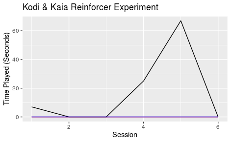

```r
gf_line(Kodi.Kaia.Rein$`Attention Control`~Kodi.Kaia.Rein$Session) %>% gf_line(Kodi.Kaia.Rein$`Attention Test`~Kodi.Kaia.Rein$Session, color = 'red') %>% gf_line(Kodi.Kaia.Rein$Alone~Kodi.Kaia.Rein$Session, color = 'blue') %>% gf_labs(title = 'Kodi & Kaia Reinforcer Experiment', x = 'Session', y = 'Time Played (Seconds)')
```

The above shows descriptives for the reinforced dataset of my assigned dog pairs. The plots indicate sessions (x-axis) with time played in seconds (y-axis) and the three different colored lines indicate the 3 reinforced variables of attention test, attention control, and alone. # 5 March 2020

#### SD Data Analysis

```r
wilcox.test(Sally.Vanya$`Percent of Scored Intervals in SD...10`, Sally.Vanya$`Percent of Scored Intervals in S-delta...11`, alternative = c("two.sided"))
```

```
cannot compute exact p-value with ties
```

```
    Wilcoxon rank sum test with continuity correction

data:  Sally.Vanya$`Percent of Scored Intervals in SD...10` and Sally.Vanya$`Percent of Scored Intervals in S-delta...11`
W = 58.5, p-value = 0.5398
alternative hypothesis: true location shift is not equal to 0
```

The Mann-Whitney U test shows a p-value of 0.5398 which is not significant enough to reject the null hypothesis. We cannot conclude that the distributions of the SD and S-Delta are different for Sally and Vanya.

```r
curve(dt (x, df = 13.574), xlim = c(-3, 3), main = 'Sally & Vanya T-Distribution', xlab = 't-statistic', ylab = 'Density')
abline(v = 0.51729, col = 'blue')
```

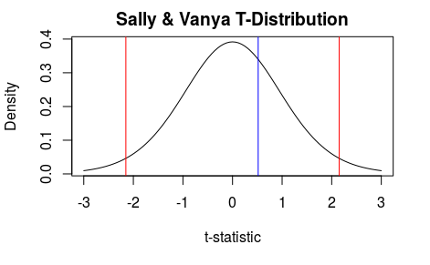

```r
abline(v = qt(.025, df = 13.574), col = 'red')
abline(v = qt(.975, df = 13.574), col = 'red')
```

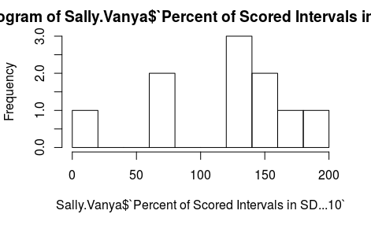

```r
hist(Sally.Vanya$`Percent of Scored Intervals in SD...10`, breaks = 10)
```

```r
shapiro.test(Sally.Vanya$`Percent of Scored Intervals in SD...10`)
```

```
    Shapiro-Wilk normality test

data:  Sally.Vanya$`Percent of Scored Intervals in SD...10`
W = 0.91093, p-value = 0.2874
```

# 24 March 2020

#### SD Data Analysis

### Kobe & Ian

```r
wilcox.test(Kobe.Ian$'SD', Kobe.Ian$`S-Delta`, alternative = c("two.sided"))
```

```
cannot compute exact p-value with ties
```

```
    Wilcoxon rank sum test with continuity correction

data:  Kobe.Ian$SD and Kobe.Ian$`S-Delta`
W = 100, p-value = 6.386e-05
alternative hypothesis: true location shift is not equal to 0
```

The Mann-Whitney U test shows a p-value of 6.386e-05 which is significant enough to reject the null hypothesis. We can conclude that the distributions of the SD and S-Delta are different for Kobe and Ian.

### Rocky & Oaky

```r
wilcox.test(Rocky.Oaky$`SD (s)`, Rocky.Oaky$`S-Delta (s)`, alternative = c("two.sided"))
```

```
cannot compute exact p-value with ties
```

```
    Wilcoxon rank sum test with continuity correction

data:  Rocky.Oaky$`SD (s)` and Rocky.Oaky$`S-Delta (s)`
W = 100, p-value = 6.34e-05
alternative hypothesis: true location shift is not equal to 0
```

The Mann-Whitney U test shows a p-value of 6.34e-05 which is significant enough to reject the null hypothesis. We can conclude that the distributions of the SD and S-Delta are different for Rocky and Oaky.

### Rosie & Carlie

```r
wilcox.test(Rosie.Carlie$`SD (s)`, Rosie.Carlie$`S-Delta (s)`, alternative = c("two.sided"))
```

```
cannot compute exact p-value with ties
```

```
    Wilcoxon rank sum test with continuity correction

data:  Rosie.Carlie$`SD (s)` and Rosie.Carlie$`S-Delta (s)`
W = 85, p-value = 0.002178
alternative hypothesis: true location shift is not equal to 0
```

The Mann-Whitney U test shows a p-value of 0.002178 which is significant enough to reject the null hypothesis. We can conclude that the distributions of the SD and S-Delta are different for Rosie and Carlie.

### Koda & Ava

```r
wilcox.test(Koda.Ava$`SD (Attention)`, Koda.Ava$`S-Delta (No Attention)`, alternative = c("two.sided"))
```

```
cannot compute exact p-value with ties
```

```
    Wilcoxon rank sum test with continuity correction

data:  Koda.Ava$`SD (Attention)` and Koda.Ava$`S-Delta (No Attention)`
W = 55, p-value = 0.3681
alternative hypothesis: true location shift is not equal to 0
```

The Mann-Whitney U test shows a p-value of 0.3681 which is not significant enough to reject the null hypothesis. We can not conclude that the distributions of the SD and S-Delta are different for Koda and Ava. ### Kodi & Kaia

```r
wilcox.test(Kodi.Kaia$`SD (s)`, Kodi.Kaia$`S-Delta (s)`, alternative = c("two.sided"))
```

```
cannot compute exact p-value with ties
```

```
    Wilcoxon rank sum test with continuity correction

data:  Kodi.Kaia$`SD (s)` and Kodi.Kaia$`S-Delta (s)`
W = 82, p-value = 0.01095
alternative hypothesis: true location shift is not equal to 0
```

The Mann-Whitney U test shows a p-value of 0.01095 which is significant enough to reject the null hypothesis. We can conclude that the distributions of the SD and S-Delta are different for Kodi and Kaia.

#### Kruskall-Wallis Tests for Reinforcer Data

### Sally & Vanya

```r
library(dunn.test)
kruskal.test(Sally.Vanya.Rein$`Attention Control`, Sally.Vanya.Rein$`Attention Test`, Sally.Vanya.Rein$Alone)
```

The kruskall-wallis test will not be used and is unsuccessful for the reinforced dataset because it is an independent test and a repeated measure ANOVA test would work best.

## Loading in Reinforcer Data

```r
Kobe.Ian.Rein = read_excel('Reinforcer_Data.xlsx', sheet = 'P1_Kobe&Ian')
Sally.Vanya.Rein = read_excel('Reinforcer_Data.xlsx', sheet = 'P2_Sally&Vanya')
```

```
* `` -> ...6
* `` -> ...7
* `` -> ...8
* `` -> ...9
* `` -> ...10
```

```r
Rocky.Oaky.Rein = read_excel('Reinforcer_Data.xlsx', sheet = 'P3_Rocky&Oaky')
```

```
* `` -> ...6
* `` -> ...7
* `` -> ...8
* `` -> ...9
* `` -> ...10
```

```r
Rosie.Carlie.Rein = read_excel('Reinforcer_Data.xlsx', sheet = 'P4_Rosie&Carlie')
```

```
* `` -> ...6
* `` -> ...7
* `` -> ...8
* `` -> ...9
```

```r
Jude.Luna.Rein = read_excel('Reinforcer_Data.xlsx', sheet = 'P5_Jude&Luna')
Kodi.Kaia.Rein = read_excel('Reinforcer_Data.xlsx', sheet = 'P6_Kodi & Kaia')
```

```
* `` -> ...6
```

# 26 March 2020

## Loading in MASTER files

```r
SD.Master = read_excel('SD_Data.xlsx', sheet = 'SD Master')
EO.Master = read_excel('EO_Data.xlsx', sheet = 'EO Master')
Rein.Master = read_excel('Play Exp 3 (Reinforcer) Data MASTER.xlsx', sheet = 'Master Reinforcer')
```

Consolidated all datasheets into separate Master sheets to make it easier to run code collectively in R

## Descriptives of Overall Statistics

#### SD Dataset

I (Sonny) will run these calculations and have it set for tuesdays presentation.

# 28 March 2020

## Descriptives of Overall Statistics

#### SD Dataset

```r
favstats(~SD.Master$`SD (s)`)
```

|  | min | Q1 | median | Q3 | max | mean | sd | n | missing |
| --- | --- | --- | --- | --- | --- | --- | --- | --- | --- |
|  | 0 | 16.75 | 76.5 | 154.5 | 285 | 92.40833 | 79.46962 | 120 | 0 |

```r
favstats(~SD.Master$`S-Delta (s)`)
```

|  | min | Q1 | median | Q3 | max | mean | sd | n | missing |
| --- | --- | --- | --- | --- | --- | --- | --- | --- | --- |
|  | 0 | 0 | 0 | 0 | 270 | 18.6 | 51.44964 | 120 | 0 |

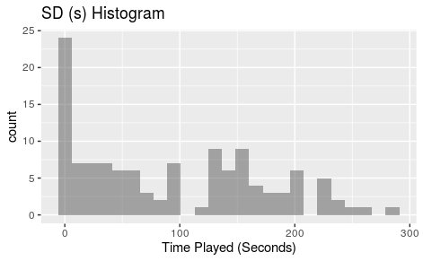

```r
gf_histogram(~SD.Master$`SD (s)`) %>% gf_labs(x = 'Time Played (Seconds)', title = 'SD (s) Histogram')
```

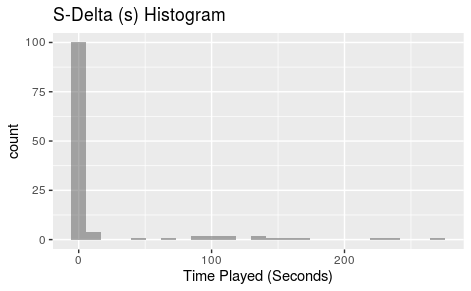

```r
gf_histogram(~SD.Master$`S-Delta (s)`) %>% gf_labs(x = 'Time Played (Seconds)', title = 'S-Delta (s) Histogram')
```

Above are the descriptive statistics of the overall SD master files. The first histogram for SD (s) indicates data that is not normal because it is not a a symmetric histogram. It appears to have a right tail that is stretched thus being positively skewed.

The second histogram for S-Delta (s) indicates data that is not normalized. Majority of the data is congested on the left side between 0 and 20 seconds.

Higher mean and standard deviation for SD data than S-Delta data. This makes sense because there is less playing time among the dogs that were given no attention.